# Análise do corpo discente da UNESP Bauru

## INTRODUÇÃO

Nosso projeto foi baseado na análise populacional coletada pelos alunos da turma de Ciência de Dados no segundo semestre de 2018. O objetivo principal do trabalho era responder a questão: *Quais são as influências das mídias sociais sobre discentes da instituição de nível superior UNESP-Bauru-SP?*

Desta maneira, durante o projeto coletamos dados de alunos da instituição para que pudéssemos responder questões sobre utilização de dispositivos informacionais em relação ao ambiente acadêmico e profissional.

## Estagiários e LinkedIn

Analisamos que entre as maiores porcentagens entre os empregados entrevistados, encontram-se os estagi?rios, e entre estes, a maioria utiliza a rede social LinkedIn.

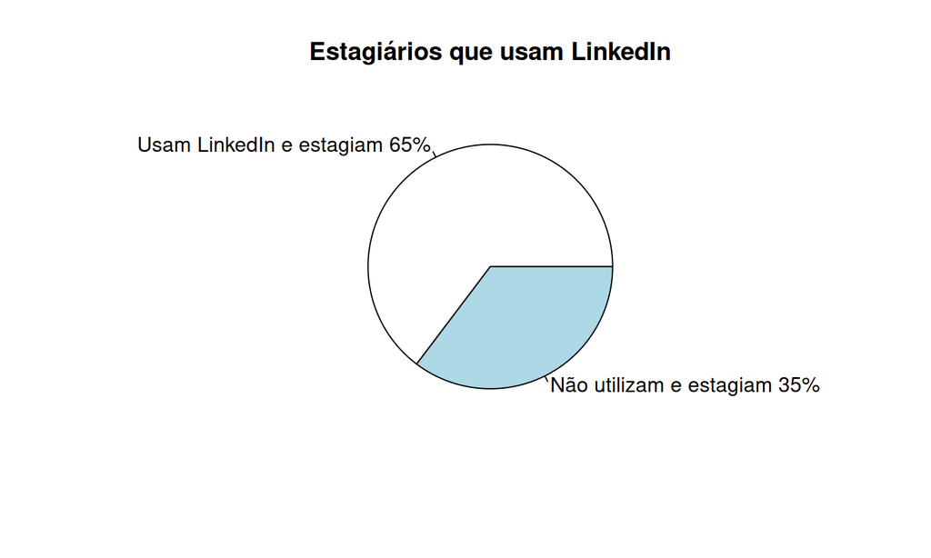

## Jornada Parcial e LinkedIn

Analisamos que entre as maiores porcentagens entre os empregados entrevistados, encontram-se as pessoas que fazem jornada parcial, e entre estes, há uma divisão igualitária entre quem utiliza e quem não utiliza a rede social LinkedIn.

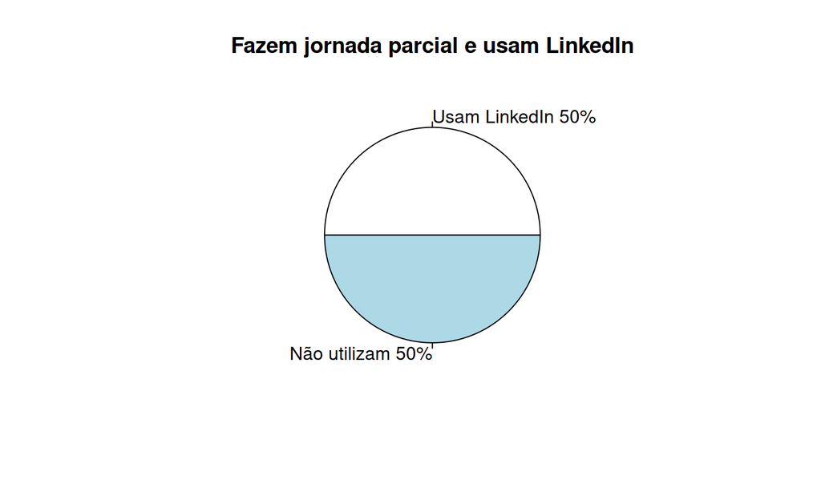

## As redes sociais podem melhorar os resultados dos alunos?

Embora o uso das redes sociais como apoio aos professores ainda divida opiniões, é de consentimento geral que o debate, nessa etapa da discussão, é essencial.

Uma universidade pública como a UNESP compreende uma parcela de público diversificada e, portanto, muito importante para essa discussão.

### Opinião dos participantes

Aprofundando-se na opinião dos entrevistados, verificamos um aceno significativo, onde mais de 60% vê as redes sociais como uma opção interassante de ferramenta a fim de melhorar o ensino.

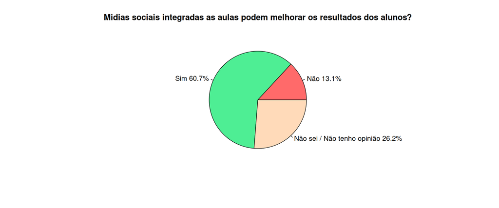

A informação, no entanto, diz pouco sobre a opinião do público da pesquisa acerca do tema, deixando questões como por responder.

### As respostas e o tempo

Um ponto importante é a relação pessoal de uso que dos participantes têm com essas mídias, já que é sensato imaginar que sua opinião está intimamente ligada a maneira como eles vêm e entendem essas redes.

Como forma de analisar a questão apresentamos alguns gráficos que relacionam o tempo gasto dos entrevistados e sua opinião sobre o uso das mídias sociais.

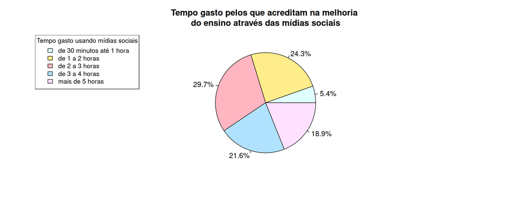

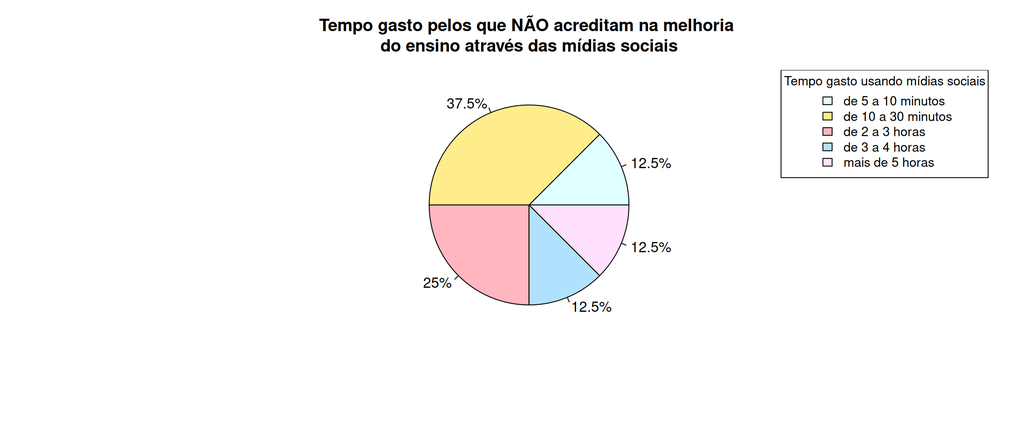

Podemos ressaltar dois pontos importantes:

- A maioria absoluta dos que defendem as mídias como ferramenta usa as mesmas por pelo menos 1 hora ao dia (quase 95%!!) e que TODOS usam por meia hora ou mais
- Embora os tempos dos que não acreditam nas redes sociais como ferramenta de consumo sejam distribuídos, metade não usa redes sociais por mais de 30 minutos no dia!

Para uma visão panorâmica da questão, apresentamos um terceiro gráfico:

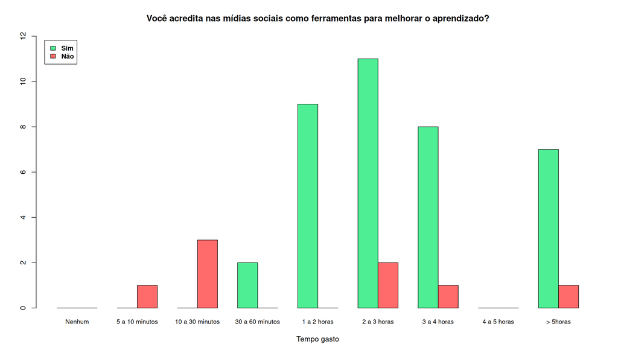

No gráfico fica evidente tanto a grandeza da opinião positiva sobre a negativa, quanto a relação de que as opiniões postivas tendem a se concentrar nos entrevistados que passam mais tempo *online*.

Dessa forma, verificamos que aqueles que tem mais "intimidade" com as redes tambem as vêm com potencial para o ensino.